# Gender Data Lab Workshop in Rwanda

Shu Fu (SJTU) and PARIS21

2024-08-12

$~$

# Day 1 Session 1: Programming 101

$~$

## 1. R

$~$ $~$

[R](https://www.r-project.org/) is a versatile, open source programming and scripting language that is especially powerful for data exploration, visualization, and statistical analysis. Some of its **best features** are:

$~$

- It’s **free**, open source.
- It contains massive set of **packages** for importing and manipulating data, visualization, statistical analysis, and even machine learning. Whatever model or graphic you’re trying to do, chances are that someone has already tried to do it (and a package for it exists).
- It’s designed for statistics and data analysis, but also general-purpose programming. Therefore, it is easy to reproduce analyses **repeatedly**.

$~$

Of course, R also has some **shortcomings**:

$~$

- It has a steeper learning curve than Excel or STATA.
- R is not a particularly fast programming language, and poorly written R code can be terribly slow. R is also a profligate user of memory.
- Inconsistency is rife across contributed packages, even within base R. You are confronted with over 20 years of evolution every time you use R. Learning R can be tough because there are many special cases to remember.

$~$

To download R, go to [CRAN](https://cran.r-project.org/) (the Comprehensive R Archive Network).

$~$

## 2. R Studio

$~$ $~$

To interact with R, we use RStudio. Please install the latest desktop version of [RStudio IDE](https://rstudio.com/products/rstudio/download/).

First time users often confuse the two. At its simplest R is like a car’s engine while RStudio is like a car’s dashboard.

R: Engine

RStudio: Dashboard

[figure not shown]

[figure not shown]

$~$

More precisely, R is a programming language that runs computations, while RStudio is an integrated development environment (IDE) that provides an interface with many convenient features and tools. So just as the way of having access to a speedometer, rear-view mirrors, and a navigation system makes driving much easier, using RStudio’s interface makes using R much easier as well.

$~$

RStudio includes a console, syntax-highlighting code editor, as well as tools for plotting, history, debugging and workspace management. It’s also free and open-source. Oh, yah!

$~$

After you install R and RStudio on your computer, you’ll have two new applications you can open. We’ll always work in RStudio– not in the R application.

$~$

R: Do not open this

RStudio: Open This

$~$ After you open RStudio, you should see something similar to this:

$~$

[figure not shown]

$~$

For now, all you need to know is that you type R code in the console pane, and press enter to run it. You’ll learn more as we go along!

$~$

## 3. R Basics

$~$

### 3.1 Console

$~$

There are two main ways of interacting with R; by using the console or by using the script editor.

$~$

The console window (in RStudio, the bottom left panel) is the place where R is waiting for you to tell it what to do and where it will show the results of a command.

$~$

You can type commands directly into the console, but they will be forgotten when you close the session. Let’s give it a try.

$~$

```r
> 1 + 1
```

$~$

If R is ready to accept commands, the R console shows a `>` prompt. If it receives a command (by typing, copy-pasting, or sending them from the script editor using `Cmd + Return` (in Mac) or `Ctrl + Enter` (in Windows), R will try to execute it and when ready, show the results and come back with a new `>` prompt to wait for new commands.

$~$

If R is still waiting for you to enter more data because it is not complete yet, the console will show a `+` prompt. It means that you have not finished entering a complete command. This happens when you have not “closed” a parenthesis or quotation. If you are in RStudio and this happens, click inside the console window and press `Esc`; this should help you get you out of trouble.

$~$

```r
> "This is an imcomplete quote
+
```

$~$

*Note*: If your zodiac constellation is Virgo—known for being perfectionists—you will find `Ctrl + L` (in both Mac and Windows) helpful, because it clears your console, while preserves the command history.

$~$

## 3.2 Scripts

$~$

It is better practice to enter commands in the *script editor* and save the script. This way, you have a complete record of what you do, you can easily show others how you do it, and you can do it again later on if needed. Open it up either by clicking the File menu and selecting New File, then R script; or simply press the top-left button with a green plus sign on the white paper. Now you will see four panes.

$~$

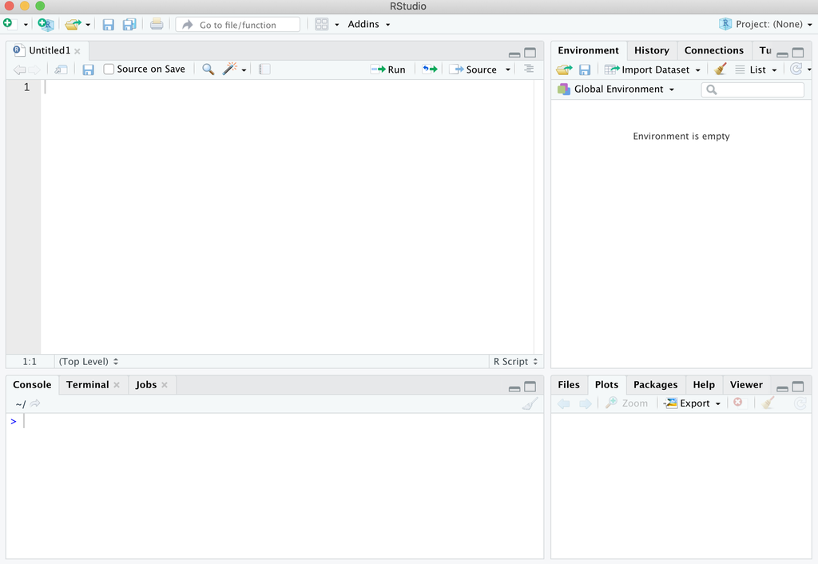

$~$

## 3.3 Running Code

$~$

While you certainly can copy-paste code that you would like to run from the editor into the console, this workflow is pretty inefficient. The key to using the script editor effectively is to memorize one of the most important keyboard shortcuts in RStudio: `Cmd + Return` (in Mac) or `Ctrl + Enter` (in Windows). This executes the line/lines of code where your cursor is located from the script editor in the console.

$~$

You can also select multiple lines of code and then press `Cmd + Return` (in Mac) or `Ctrl + Enter` (in Windows) to run them all.

$~$

## 3.4 Comments

$~$

Use `#` signs to add comments within your code chunks. You are encouraged to regularly comment within your code. Anything to the right of a `#` is ignored by R. Each line of a comment needs to begin with a `#`.

$~$

```r
# This is a comment.
# This is another line of comments.
```

$~$

## 3.5 R as a Calculator

$~$

R is the last calculator you will ever need. It can perform virtually any style of computation, including calculus and matrix algebra operations. There is not time for a full treatment of all the types of commands here, but just to get things going, we’ll start with a few simple examples.

$~$

```r
4 + 4     # addition

6 - 2     # subtraction

100 / 10  # division

450 * 3   # multiplication

8 ^ 2     # raise a number to a power

sqrt(64)  # square root

pi        # the constant pi

log(10)   # the natural log

exp(10)   # exponentiate

exp(log(10))

10 %% 2   # remainders: 2 goes into 10 five times, no remainder

11 %% 2   # 2 goes into 11 five times, remainder = 1
```

$~$

## 3.6 Challenge

$~$

Open a new script editor, write several lines of code to calculate the following:

1. $\frac{73 + 84}{25 - 4}$
2. $log(\pi)$
3. Divide $(2022 ^ 2) \times 7$ by 3, what’s the remainder?

$~$

## 4. R Packages

$~$

### 4.1 R Packages Installation and Load

$~$

One of the best parts about R is its user-contributed packages (also called “libraries”). A *package* is a collection of functions (and sometimes data) that can be used by other programers.

$~$

A good analogy for R packages is they are like apps you can download onto a mobile phone:

$~$

[figure not shown]

$~$

R is like a brand new mobile phone: while it has a certain amount of features when you use it for the first time, it doesn’t have everything. R packages are like the apps you can download onto your phone from Apple’s App Store or Android’s Google Play.

$~$

Using packages in R is almost a must. The process of using packages is very similar for using an app on your mobile phone. You need to:

$~$

**Install the package**: This is like installing an app on your phone. Most packages are not installed by default when you install R and RStudio. Thus if you want to use a package for the first time, you need to install it first. Once you’ve installed a package, you likely won’t install it again unless you want to update it to a newer version.

$~$

For example, let’s download the package `stargazer`, which is a wonderful package for generating regression tables in R. Remember, when you install a package, you should have **quotation marks** on the package name.

$~$

```r
install.packages("stargazer")
```

$~$

**“Load” the package**: Loading a package is like opening an app on your phone. Packages are not loaded by default when you start RStudio on your computer; you need to load each package you want to use every time you start RStudio. A new R session will not automatically load every package we have ever downloaded. When you load a new package, you need to use `library` function, and you don’t need to have quotation marks on the package name.

$~$

```r
library(stargazer)
```

$~$

### 4.1 Let’s Install Packages

$~$

Let’s go ahead and download some core, important packages we’re going to use for the rest of the course. Download (if you haven’t done so already) and load the following packages:

$~$

- `tidyverse`
- `readxl`
- `readr`
- `gapminder`
- `ggthemes`

$~$

*Suggestions*: You can download the packages in the console directly, because once you’ve downloaded a package, you don’t need to re-download it later. But when you load these packages, you are suggested to write code in an R script and then execute it.

$~$

## 5. R Syntax

$~$

Frustration is natural when you start programming in R. R is a stickler for punctuation, and even one character out of place will cause it to complain. But while you should expect to be a little frustrated, take comfort in that it is both typical and temporary: it happens to everyone, and the only way to get over it is to keep trying.

$~$

To understand computations in R, two slogans are helpful:

- Everything that exists is an **object**.
- Everything that happens is a **function** call.

$~$

### 5.1 Objects

$~$

#### 5.1.1 Assigning Values to Objects

$~$

An essential part of programming is creating objects. An object is created when a value is assigned to it. We do that with `<-`. The `<-` symbols is known as “gets” because of the operation it performs: the object on the left hand side “gets” the value you place on the right hand side. You can use the shortcut `option/alt + -`.

$~$

```r
x <- 3
y <- 5 * 3
```

$~$

So, after executing `x <- 3`, the value of `x` is `3`. And it is stored in the environment. You can show it’s value by simply type the object name; or you can use objects in calculations just as if they were values.

$~$

```r
x
# [1] 3
x + y
# [1] 18
```

$~$

**Note**: Do not use `=` for assignments. It will work in some contexts, but it will cause confusion later. There will be other scenarios where you will use `=`, we will discuss these later on.

$~$

**Whitespace** makes code easier to read. Notice that we surrounded `<-` with spaces. In R, white space is ignored (unlike Python). It is good practice to use spaces, because it makes code easier to read.

$~$

```r
trump_slogan <- "Make America Great Again!"    # this is good
trump_slogan<-"Make America Great Again!"      # this is bad
```

$~$

#### 5.1.2 Object Names

$~$

Object names can only contain letters, numbers, `_` and `.`. Remember, there is no whitespace inside an object names.

$~$

You want your object names to be descriptive. `x` is not a good name (sorry!). You will also need a convention for multiple words. I recommend “snake_case”, where you separate lowercase words with `_`.

```r
i_use_snake_case
otherPeopleUseCamelCase
some.people.use.periods

this_is.a_BAD_name
```

$~$

#### 5.1.3 Challenges

$~$

**a. Making and printing variables**:

Make 3 variables, name (with your full name), city (where you were born), and year (when you were born).

$~$

**b. Predicting values**:

What is the final value of position in the program below? Try to predict the value without running the program, then check your prediction.

```r
initial <- "left"
position <- initial
initial <- "right"
```

$~$

**c. Syntax**

Why does the following code fail?

```r
age == 31
```

And the following?

```r
31 <- age
```

$~$

### 5.2 Functions

$~$

Functions in R operate just like functions in mathematics: they take an input, perform some pre-specified operation, and produce an output.

$~$

R has a large collection of built-in functions that helps us do things. Here are some helpful built-in functions:

$~$

```r
numbers <- c(1, 5, 2, 4, 5)

sum(numbers)
# [1] 17
length(numbers)
# [1] 5
min(numbers)
# [1] 1
max(numbers)
# [1] 5
unique(numbers)
# [1] 1 5 2 4
```

$~$

#### 5.2.1 Arguments

$~$

An **argument** is a value that is *passed* into a function. Some functions need one argument, some require more than one arguments. For example,

$~$

```r
round(pi, 2)
# [1] 3.14
```

How many arguments did we pass into the `round` function?

$~$

#### 5.2.2 Store Function Output

$~$

Notice that, when we called the `round` function, nothing changed in our environment. That is because we did not save our results to an object. Let’s try it again by assigning a variable:

$~$

```r
y <- round(pi, 2)
y
# [1] 3.14
```

$~$

#### 5.2.3 Argument Restrictions and Defaults

$~$

Functions may have **default** values for some arguments. By default, round will round off any number to zero decimal places. But we can specify the number of decimal places we want.

$~$

```r
round(pi)
# [1] 3
round(pi, digits = 2)
# [1] 3.14
round(pi, 2)
# [1] 3.14
```

$~$

How do we know what kinds of arguments to pass into a function? Every built-in function comes with **documentation**.

$~$

- `?` + object opens a help page for that specific object.
- `??` + object searches help pages containing the name of the object.

$~$

```r
?round
??round
```

$~$

### 5.2.4 Challenges

$~$

**a. What Happens?**

R has built-in functions to calculate the max and min values, `max` and `min`. Explain, in simple terms, the order of operations in the following program: When does the addition happen, when does the subtraction happen, when is each function called, etc.

What is the final value of `radiance`?

```r
radiance <- 1.0
radiance <- max(2.1, 2.0 + min(radiance, 1.1 * radiance - 0.5))
```

$~$

**b. Why?**

Run the following code.

```r
rich <- "gold"
poor <- "wood"
max(rich, poor)
```

Using the help files for `max`, explain why it returns the result it does.

$~$

### 5.3 Data Types

$~$

Every object has a specific type. In R, those types are called “classes”, and there are 3 of them:

- Numeric (integer or double)
- Character (string)
- Logical (TRUE or FALSE booleans)

$~$

#### 5.3.1 What is that Type?

$~$

Every piece of information in R has a type! Use the build-in function `class` to find out what type a value has.

$~$

```r
class(3)
# [1] "numeric"
class("three")
# [1] "character"
class(TRUE)
# [1] "logical"
```

$~$

This works on objects as well.

$~$

```r
three <- 3
class(three)
# [1] "numeric"

three <- "three"
class(three)
# [1] "character"
```

$~$

An object’s class determines what the program can do to it.

$~$

```r
3 - 1
# [1] 2

3 - "1"
# Error in 3 - "1" : non-numeric argument to binary operator
```

$~$

#### 5.3.2 Coercion

$~$

We just learned we cannot subtract numbers and strings. Instead, use `as.` + name of class as a function to convert a value to a specific type.

$~$

```r
3 - as.numeric("1")
# [1] 2
as.character(20220101)
# [1] "20220101"
```

$~$

This is called **coercion**. Here is another example:

$~$

```r
my_var <- "FALSE"
my_var
# [1] "FALSE"
as.logical(my_var)
# [1] FALSE
```

$~$

What difference did you notice?

$~$

#### 5.3.3 Other Objects

$~$

There are a few other “odd ball” types in R:

$~$

**`NA` are missing values.** NA will always be coerced to the correct type if used inside `c()`.

$~$

```r
x <- c(1, 5, NA)
x
# [1] 1 5 NA
class(NA)
# [1] "logical"
class(x)
# [1] "numeric"
```

$~$

**`Inf` is infinity.**

$~$

```r
1 / 0
# [1] Inf
1 / Inf
# [1] 0
```

$~$

**`NaN` means “not a number.” It is an undefined value.**

$~$

```r
0 / 0
# [1] NaN
```

$~$

#### 5.3.4 Challenges

$~$

**a. Making and Coercing Variables**

- Make a variable `year` and assign it as the year you were born.
- Coerce that variable to a string and assign it to a new variable `year_string`.
- Someone in our classroom says he was born in 1989. Really? Really! Find out what your age difference is, using only `year_string`.

$~$

### 5.4 Boolean Expressions

$~$

Boolean expressions are logical statements that are either true or false. For our purposes, we will often use Boolean expressions to compare quantities. For instance, the Boolean expression 1 < 2 is `TRUE`, whereas the Boolean expression 1 > 2 is `FALSE`.

$~$

#### 5.4.1 Boolean Operators

$~$

| Operator | Description |
| --- | --- |
| `<` | less than |
| `<=` | less than or equal to |
| `>` | greater than |
| `>=` | greater than or equal to |
| `==` | exactly equal to |
| `!=` | not equal to |
| `%in%` | is an item of a set |

$~$

Note that we use a double equal sign `==` to check whether two values are equal. Typing `a = b` would set the value of `a` equal to the value of `b`.

$~$

Here are some examples of Boolean expressions in action:

$~$

```r
1 < 2
# [1] TRUE
1 > 2
# [1] FALSE
1 == 2
# [1] FALSE

value_1 <- 1
value_1 > 0
# [1] TRUE

value_2 <- value_1 + 10
value_1 + value_2 == 12
# [1] TRUE
```

$~$

#### 5.4.2 Logical Operators

$~$

In practice, we often use two or more conditions to decide what to do. To combine different conditions, there are three logical operators:

$~$

| Operator | Description |
| --- | --- |
| `&` | AND |
| `\|` | OR |
| `!` | NOT |

$~$

```r
x <- 10
y <- 20

### check to see if values are between 5 and 15
x > 5 & x < 15
# [1] TRUE
y > 5 & y < 15
# [1] FALSE

### more complex chains
(x > 5 & x < 15) & (x > y & y < 15)
# [1] FALSE
(x > 5 & x < 15) | (x > y & y < 15)
# [1] TRUE
(x > 5 & x < 15) & !(x > y & y < 15)
# [1] TRUE
```

$~$

Different operator take different precendence. It is always a good practice to use brackets to control operation ordering.

$~$

#### 5.4.3 Challenges

$~$

**a. Comparing Random Draws**

In the partially written code below, vector_1 and vector_2 each contain 5 randomized integers between 1 and 10, using the function `sample`. Using the fact that Boolean expressions are vectorized, write code that outputs:

1. A vector of length 5 such that element `i` of this vector equals `TRUE` if `vector_1[i]` is less than `vector_2[i]` and equals FALSE otherwise.
2. The number of times that element `i` of `vector_1` is less than element `i` of `vector_2`, using the `sum` function.

```r
set.seed(20240812) # This seed creates reproducible results when drawing random numbers

vector_1 <- sample(1:10, 5, replace = TRUE)
vector_2 <- sample(1:10, 5, replace = TRUE)

vector_1
# [1] 6 4 1 3 8
vector_2
# [1] 8 9 3 4 2

### CONTINUE YOUR CODE HERE
```

$~$

$~$

$~$

### Acknowledgements

This page is, in part, derived from the following sources:

1. [R for Data Science](https://r4ds.had.co.nz/) licensed under [Creative Commons Attribution-NonCommercial-NoDerivs 3.0](https://creativecommons.org/licenses/by-nc-nd/3.0/us/).
2. [R Studio Support](https://support.rstudio.com/hc/en-us/articles/200484448).
3. Rochelle Terman’s class notes for [PLSC 31101: Computational Tools for Social Science](https://plsc-31101.github.io/course/).